# Evolução das iterações do algoritmo ILS usando distância MoJo

```r
library(tidyverse)
library(brazilmaps)
library(tmap)
```

Melhor lucro encontrado para cada valor do parâmetro inv_prob_sede_existente.

A chance de mudança de sede de uma cidade na perturbação da ILS é 1/inv_prob_sede_existente. Ou seja, quanto maior o parâmetro, menos disruptiva é a perturbação.

O lucro é expressado em milhões de reais.

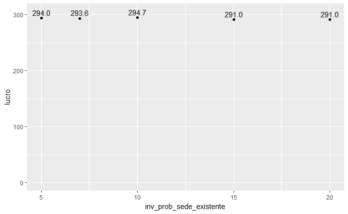

```r
calcula_custo_usina_v2 <- function(energia_GJ, num_cenario, fator_disponibilidade, alfa, beta, perc_opex){

  #fator_disponibilidade = as.double(parametros[num_cenario,"fator_disponibilidade"])
  #alfa = as.double( parametros[num_cenario,"alfa_custo_usina"])
  #beta = as.double( parametros[num_cenario,"beta_custo_usina"])
  #perc_opex = as.double( parametros[num_cenario,"percentual_OPEX"])

  #capacidade necessaria a potencia que a usina tem que ter para fazer frente a energia disponibilizada
  capacidade_necessaria = energia_GJ * MWH_por_GJ / fator_disponibilidade / (24*365)

  (alfa + beta * capacidade_necessaria) * ( 1 + perc_opex )  / anos_vida_util_usina

}
insere_receita_custo_lucro <- function(num_cenario) {

  #inserindo a receita e o custo relacionados aa biomassa. Falta o custo da usina

  custo_colheita = as.double( parametros[num_cenario,"custo_colheita_por_t"] )
  custo_armazenamento = as.double( parametros[num_cenario,"custo_armazenamento_por_t"])
  custo_carga = as.double( parametros[num_cenario,"custo_carga_por_t"])
  custo_transporte = as.double( parametros[num_cenario,"custo_transporte_por_t_km"])
  premio_produtor = as.double( parametros[num_cenario,"premio_produtor"])
  receita_por_mwh = as.double( parametros[num_cenario,"receita_por_mwh"])
  fator_disponibilidade = as.double(parametros[num_cenario,"fator_disponibilidade"])


  matriz <- matriz %>%
    mutate(
      custo =
        as.double(
          (
            custo_colheita * Carga_y +
              custo_armazenamento * Carga_y +
              custo_carga * Carga_y
          ) * ( 1 + premio_produtor)
          + custo_transporte * Carga_y * Distancia
        )) %>%

    mutate(

      receita = as.double(Energia_y * MWH_por_GJ * receita_por_mwh * fator_disponibilidade)
    ) %>%

    mutate ( lucro = receita - custo) %>%

    filter (lucro >0) %>%

    arrange( desc(lucro) )

}
#Lendo municipios e informacoes de energia e carga
municipios <-  read.csv("D:\\Mestrado Bruno\\HPC Parametrizado\\junta.csv",sep = ";", encoding = "UTF-8",dec = "," ) %>% as_tibble()
#Lendo dados de distÃ¢ncias reais entre municipios
distancias <-  read.csv("C:\\temp\\distanciarealmetros.csv",sep = "," ) %>%
  as_tibble()
distancias_inv <- distancias %>%
  rename(CD_yold = CD_y) %>%
  rename(CD_y = CD_x) %>%
  rename(CD_x = CD_yold)
distancias <- distancias %>% union(distancias_inv)
#Lendo distancias em linha reta entre municipios
distancias_retas <-  read.csv("C:\\temp\\distancia.csv",sep = "," ) %>%
  as_tibble() %>%
  rename(distancia_reta = "Distância") %>%
  rename(cod1 = cod)
#Lendo parâmetros adicionais
MWH_por_GJ = 0.27777777777777777777777778
anos_vida_util_usina = 30
parametros <-  read.csv("C:\\temp\\parametros.csv",sep = ";", encoding = "UTF-8",dec = "," ) %>% as_tibble()
#Escolhendo escopo de local da execucao
municipios_escopo_original <- municipios %>%
  filter( X.U.FEFF.UF == "SP" )
#Criando uma matriz de distancias
matriz <- municipios_escopo_original %>%
  mutate(unidade = 1) %>% #Para faxer um full outer join
  full_join(.,., by = c("unidade" = "unidade"), suffix = c("_x", "_y") ) %>%
  left_join( distancias  ) %>%
  left_join( distancias_retas ) %>%
  #distÃ¢ncias sem
  replace_na( list("Distância" = 10000) ) %>%
  rename( Distancia  =  "Distância" ) %>%
  mutate( Distancia = ifelse (Distancia <0, 10000, Distancia ))
matriz_original <- matriz
#Inserindo os custos, receitas e lucros para cada par de cidades
matriz <- insere_receita_custo_lucro(1)
matriz_so_lucro_energia <- matriz %>%
select(CD_x, CD_y, lucro, Energia_y)
Dados_brutos_1 <- read.csv("c:\\temp\\grande5-10.csv")
Dados_brutos_2 <- read.csv("c:\\temp\\grande-7-15-20.csv")
Dados_brutos <- union(Dados_brutos_1, Dados_brutos_2)
Dados_por_iteracao <- Dados_brutos %>%
    group_by(iteracao, perturbacao, inv_prob_sede_existente) %>%
    summarise(MoJo_ate_melhor = mean(MoJo_ate_melhor), lucro = mean(lucro) ) %>%
    ungroup() %>%
    group_by(inv_prob_sede_existente, perturbacao) %>%
    mutate(ultima_iteracao = max(iteracao)) %>%
    ungroup() %>%
    group_by(inv_prob_sede_existente) %>%
    mutate(perturbacao_iteracao = 10000 * perturbacao + iteracao  ) %>%
    mutate(iteracoes_concatenadas = dense_rank(perturbacao_iteracao)) %>%
    ungroup() %>%
    arrange(inv_prob_sede_existente, perturbacao, iteracao ) %>%
    mutate(MoJo_inicio = ifelse(iteracao == 1, MoJo_ate_melhor, NA ), lucro_inicio = ifelse(iteracao == 1, lucro, NA )) %>%
    mutate(MoJo_fim = ifelse(iteracao == ultima_iteracao, MoJo_ate_melhor, NA ), lucro_fim = ifelse(iteracao == ultima_iteracao, lucro, NA ) ) %>%
    identity()
Lucros <- Dados_por_iteracao %>%
    group_by(inv_prob_sede_existente) %>%
    summarise(lucro = max(lucro)/1000000)
ggplot(Lucros, aes(x = inv_prob_sede_existente, y = lucro)) +
    geom_point() +
    geom_text(nudge_y = 10, aes(label = format(lucro, digits = 4 ))) +
    expand_limits(y = 0) +
    NULL
```

A figura abaixo mostra uma comparação da evolução das iterações para cada grau de perturbação.

Os pontos verdes mostram pontos de início de cada busca local. O primeiro ponto verde representa a iteração após a solução inicial dada pelo algoritmo guloso. os outros, as soluções iniciais após as perturbações.

A distância MoJo é calculada em relação à melhor solução antes da execução da iteração.

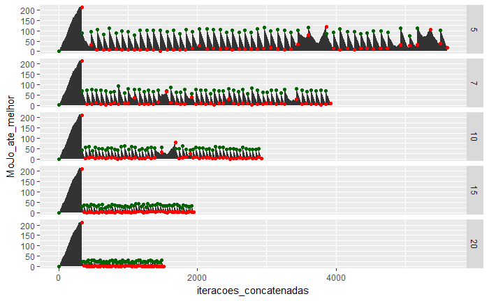

```r
ggplot(Dados_por_iteracao ) +
    geom_area(aes(x = iteracoes_concatenadas, y = MoJo_ate_melhor )) +
    geom_point(aes(x = iteracoes_concatenadas, y = MoJo_inicio ), color = "dark green") +
    geom_point(aes(x = iteracoes_concatenadas, y = MoJo_fim ), color = "red") +
    facet_grid( inv_prob_sede_existente ~ .)
```

```r
NA
```

Agora, cada uma das iterações.

E azul, a evolução dos lucros.

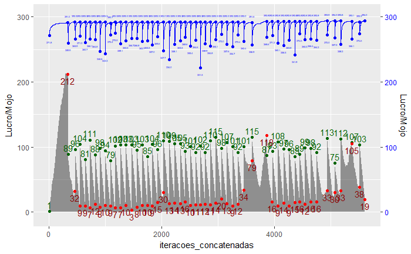

```r
Dados_por_iteracao_5 <- Dados_por_iteracao %>%
    filter(inv_prob_sede_existente == 5 )
Dados_por_iteracao_7 <- Dados_por_iteracao %>%
    filter(inv_prob_sede_existente == 10)
Dados_por_iteracao_10 <- Dados_por_iteracao %>%
    filter(inv_prob_sede_existente == 10)
Dados_por_iteracao_15 <- Dados_por_iteracao %>%
    filter(inv_prob_sede_existente == 15)
Dados_por_iteracao_20 <- Dados_por_iteracao %>%
    filter(inv_prob_sede_existente == 20)
Plota <- function(dados)
{

    ggplot(dados ) +
        geom_area(aes(x = iteracoes_concatenadas, y = MoJo_ate_melhor ), alpha = 0.5) +
        geom_line(aes(x = iteracoes_concatenadas, y = lucro/1000000 ), color = "blue") +
        geom_point(aes(x = iteracoes_concatenadas, y = lucro_inicio/1000000 ), color = "blue") +
        geom_point(aes(x = iteracoes_concatenadas, y = lucro_fim/1000000 ), color = "blue") +
        geom_text(nudge_y = -10, color = "blue", size=1, aes( x = iteracoes_concatenadas, y = lucro_inicio/1000000, label = format(lucro_inicio/1000000, digits = 4 ))) +
        geom_text(nudge_y = 10, color = "blue", size=1, aes( x = iteracoes_concatenadas, y = lucro_fim/1000000, label = format(lucro_fim/1000000, digits = 4  ))) +
        geom_point(aes(x = iteracoes_concatenadas, y = MoJo_inicio ), color = "dark green") +
        geom_point(aes(x = iteracoes_concatenadas, y = MoJo_fim ), color = "red") +
        geom_text(nudge_y = 10, aes(x = iteracoes_concatenadas, y = MoJo_inicio,  label = MoJo_inicio ), color = "dark green") +
        geom_text(nudge_y = -10, aes(x = iteracoes_concatenadas, y = MoJo_fim,  label = MoJo_fim ), color = "dark red") +
        scale_y_continuous("Lucro/Mojo",sec.axis = dup_axis() ) +
        theme(axis.text.y.right = element_text(color = "blue"))


}
Plota(Dados_por_iteracao_5)
```

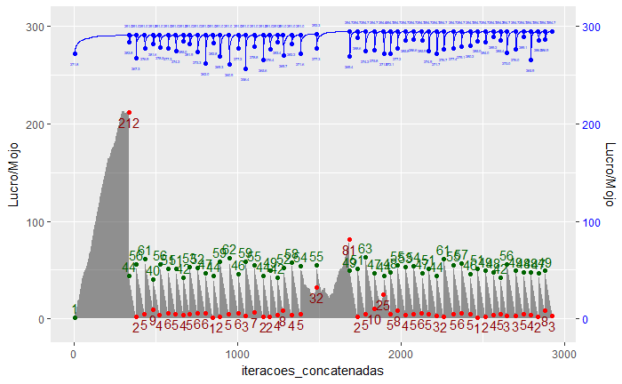

```r
Plota(Dados_por_iteracao_7)
```

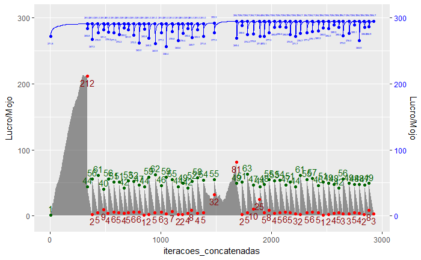

```r
Plota(Dados_por_iteracao_10)
```

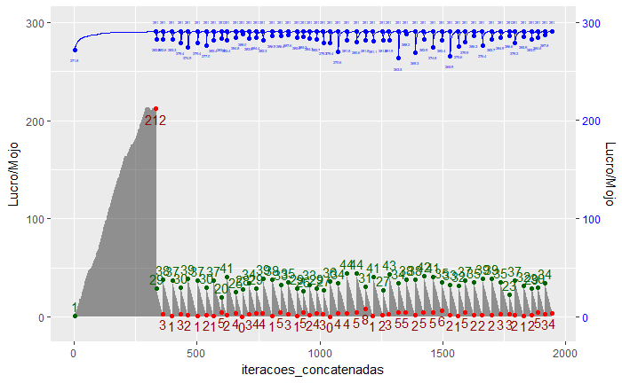

```r
Plota(Dados_por_iteracao_15)
```

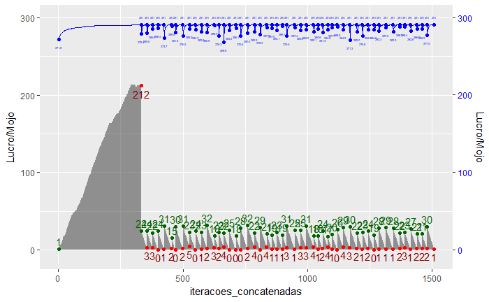

```r
Plota(Dados_por_iteracao_20)
```

Solução antes da primeira perturbação. Ou seja, da primeira busca local após a solução do algoritmo guloso.

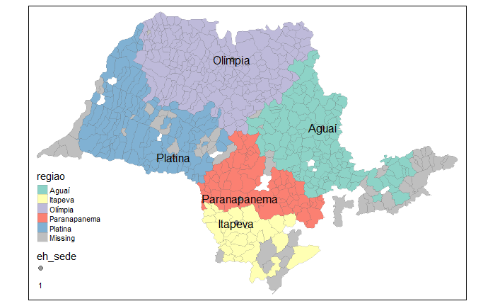

```r
limpa_particoes <- function(particoes){
  #Jogando as cidades sem lucro para a região para a partição vazia
  particoes <- particoes %>%
    left_join(matriz_so_lucro_energia, c("sede" = "CD_x", "cidades" = "CD_y" ))
  #particoes <- particoes %>%
  #  mutate(sede = if_else(is.na(lucro), as.integer(-1), sede ), label = if_else(is.na(lucro), as.integer(0), label ) ) %>%
  #  select(sede, cidades, label, iteracao) %>%
  #  identity()
  particoes

}
gera_mapa_da_particao <- function(particao_avaliar_1, particao_avaliar_2, marca_especiais ){


  particoes_com_nome <- limpa_particoes(particao_avaliar_1) %>%
    left_join( municipios_escopo, by = c("sede" = "CD") ) %>%
    select (sede, cidades, Nome) %>%
    rename( regiao = Nome ) %>%
    mutate( regiao = if_else(cidades == 3541208 & marca_especiais, "P. BERNARDES", as.character(regiao) )   )  %>%
    mutate( regiao = if_else(cidades == 3553906 & marca_especiais, "TARABAI", as.character(regiao) )   )  %>%
    mutate (regiao = fct_drop( regiao )) %>%
    mutate( nome_sede = regiao ) %>%
    mutate( nome_sede = (ifelse(sede == cidades, as.character(nome_sede), NA )) ) %>%
    mutate(eh_sede = ifelse(sede == cidades, 1, 0) ) %>%
    mutate(transp_borda = 0.4 )

  cidades <- get_brmap(geo = "City")

  UFs <- get_brmap(geo = "State")

  cidades <- sp::merge(cidades, particoes_com_nome, by.x = "City", by.y = "cidades"  )

  cidade_perdida <- cidades %>%  filter(City == 3515301)


  sedes_das_particoes <- particao_avaliar_1 %>%
    group_by(sede) %>%
    select(sede, iteracao) %>%
    filter(sede != -1) %>%
    distinct(sede)



  sedes <- sp::merge(cidades, sedes_das_particoes, by.x = "City", by.y = "sede"  )


    tm_shape(cidades) +
        tm_borders(alpha = 0.2) +
        tm_fill(col ="regiao" ) +
        tm_bubbles(size ="eh_sede", size.lim = c(0.1, 1.1), scale = 0.5  ) +
        tm_text(text = "nome_sede") +
    #tm_shape(cidade_perdida) +
    #    tm_borders(cidade_perdida) +
        NULL
}
municipios <-  read.csv("D:\\Mestrado Bruno\\HPC Parametrizado\\junta.csv",sep = ";", encoding = "UTF-8",dec = "," ) %>% as_tibble()
municipios_escopo <- municipios %>%
  filter( X.U.FEFF.UF == "SP" )
particao_avaliar <- Dados_brutos %>%
    filter(iteracao == 333 & perturbacao == 0, inv_prob_sede_existente == 10 ) %>%
    #filter(iteracao == 55 & perturbacao == 10, inv_prob_sede_existente == 10 ) %>%
    select(sede, cidades, label, iteracao)
gera_mapa_da_particao(particao_avaliar, particao_avaliar, marca_especiais = FALSE)
```

Uma solução de mesmo lucro da solução anterior após a última iteração da última perturbação para o parâmetro de menor grau de perturbação.

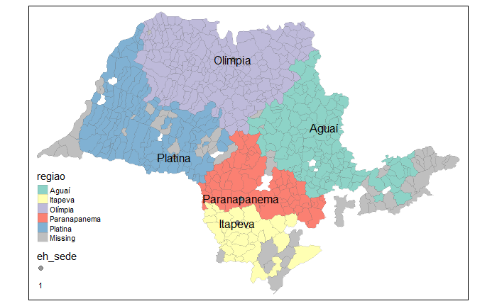

```r
particao_avaliar <- Dados_brutos %>%
    filter(iteracao == 30 & perturbacao == 50, inv_prob_sede_existente == 20 ) %>%
    #filter(iteracao == 55 & perturbacao == 10, inv_prob_sede_existente == 10 ) %>%
    select(sede, cidades, label, iteracao)
gera_mapa_da_particao(particao_avaliar, particao_avaliar, marca_especiais = FALSE)
```

Bananal, roxo na ponta, tem distância infinita para Aguaí e finita para Guaíra. Falha na busca das distâncias?

Estrela do Norte é esta cidade da região de Birigui imersa dentro da região de Ibirarema. Realmente o registro sua distância pra Birigui pela estrada é menor

Estrela do norte <-> Ibirarema: 223

Estrela do norte <-> Birigui: 219

Mas com sua sua vizinha Tarabai não acontece o mesmo… Pelas distâncias registradas isso está correto:

Tarabai <-> Birigui: 205

Tarabai <-> Ibirarema: 189

Uma vizinha mais além, Presidente Bernardes, também tem a mesma característica

Presidente Bernardes <-> Birigui: 201

Presidente Bernardes <-> Ibirarema: 194

Pode ser que a distância varie dada pelo Google Maps ao longo do tempo.

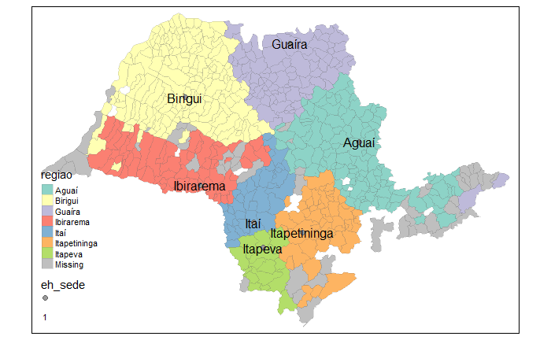

```r
particao_avaliar <- Dados_brutos %>%
    filter(iteracao == 47 & perturbacao == 50, inv_prob_sede_existente == 10 ) %>%
    #filter(iteracao == 55 & perturbacao == 10, inv_prob_sede_existente == 10 ) %>%
    select(sede, cidades, label, iteracao)
gera_mapa_da_particao(particao_avaliar, particao_avaliar, marca_especiais = FALSE)
```

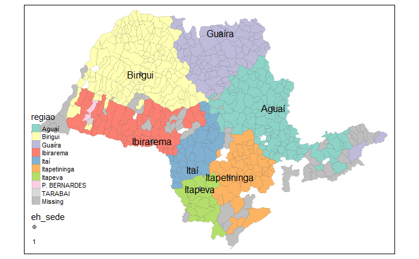

```r
gera_mapa_da_particao(particao_avaliar, particao_avaliar, marca_especiais = TRUE)
```